# Machine Learning - Fit Bit Analysis

Ashton Chevallier

Monday, May 18, 2015

We’ll be looking at fit bit data and trying to predict on whether people are actually doing excercises correctly. According to the literature in the site the definition of the “classe” variable is:

“Six young health participants were asked to perform one set of 10 repetitions of the Unilateral Dumbbell Biceps Curl in five different fashions: exactly according to the specification (Class A), throwing the elbows to the front (Class B), lifting the dumbbell only halfway (Class C), lowering the dumbbell only halfway (Class D) and throwing the hips to the front (Class E).

Read more: http://groupware.les.inf.puc-rio.br/har#ixzz3aZ2sqolq"

Here’s our code for loading and splitting the data into an additional training and testing data.

```r
  if(!file.exists("training.csv")){
        download.file("https://d396qusza40orc.cloudfront.net/predmachlearn/pml-training.csv"
                      ,destfile = "training.csv")
    }
  if(!file.exists("testing.csv")){
        download.file("https://d396qusza40orc.cloudfront.net/predmachlearn/pml-testing.csv"
                      ,destfile = "testing.csv")
    }
library(ggplot2)
library(caret)
trainingraw <- read.csv("training.csv")
validation <- read.csv("testing.csv")
set.seed(1234)
index <- createDataPartition(y=trainingraw$X,p=.8,list=FALSE)
training <- trainingraw[index,]
testing <- trainingraw[-index,]
```

The class definitions give us some clues to predicting the bad habits. Let’s start plotting some variables to see if we can see some patterns.

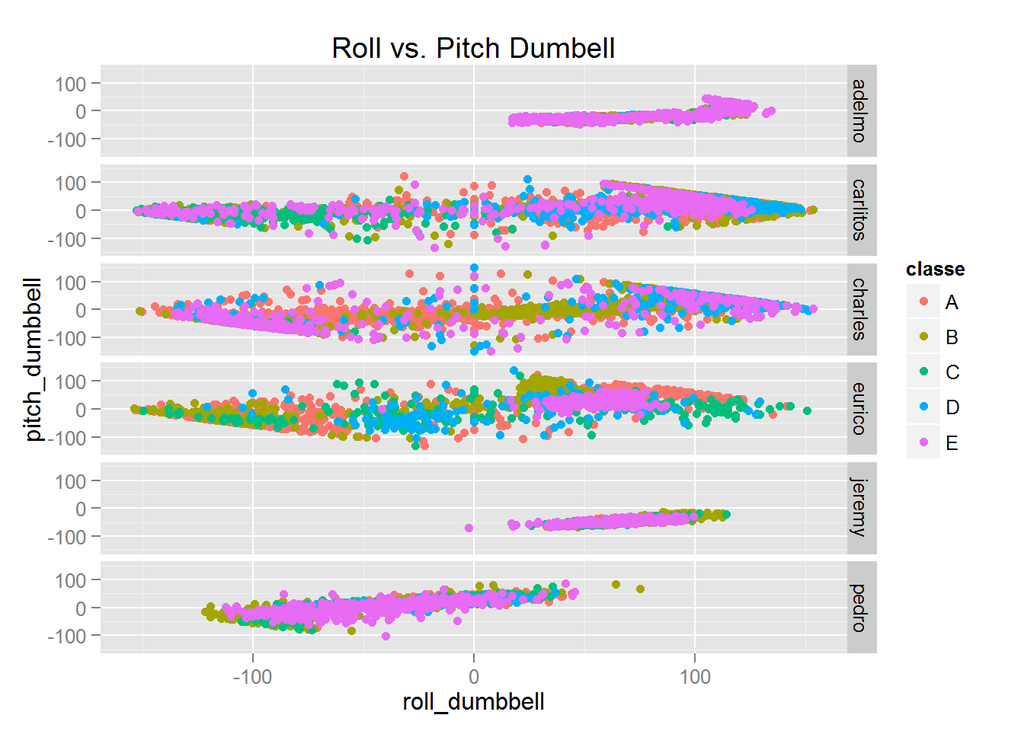

```r
qplot(data=training,roll_dumbbell,pitch_dumbbell,color=classe,facets=user_name~.,main='Roll vs. Pitch Dumbell')
```

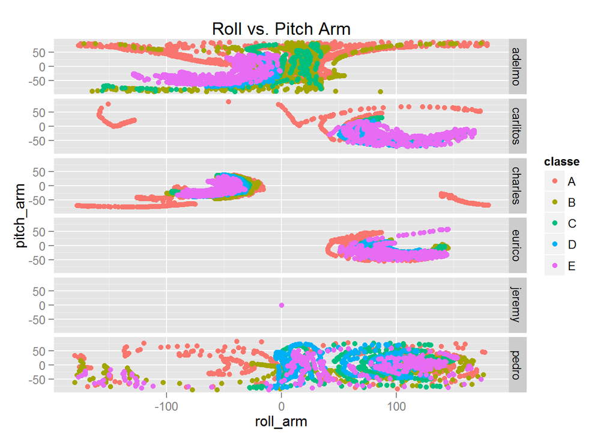

```r
qplot(data=training,roll_arm,pitch_arm,color=classe,facets=user_name~.,main='Roll vs. Pitch Arm')
```

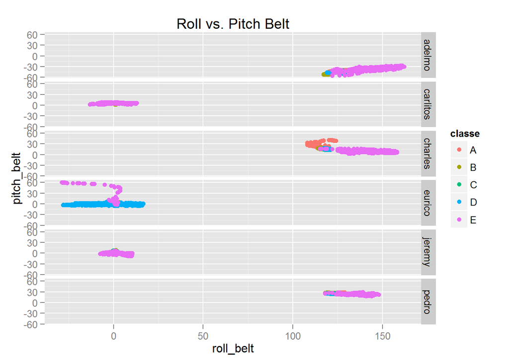

```r
qplot(data=training,roll_belt,pitch_belt,color=classe,facets=user_name~.,main='Roll vs. Pitch Belt')
```

Because the nature of these problems, a decision tree would probably end up getting confused. A random forest algorithm might work out better. To avoid potential issues and conflation with users and time stamps, we are going to filter out all the non-sesnor data first.

```r
predictors <- subset(x=training,select=c(roll_belt,pitch_belt,yaw_belt,total_accel_belt,roll_arm,pitch_arm,yaw_arm,total_accel_arm,pitch_dumbbell,roll_dumbbell,yaw_dumbbell,total_accel_dumbbell))

testpredictors <- subset(x=testing,select=c(roll_belt,pitch_belt,yaw_belt,total_accel_belt,roll_arm,pitch_arm,yaw_arm,total_accel_arm,pitch_dumbbell,roll_dumbbell,yaw_dumbbell,total_accel_dumbbell))

validationpredictors <- subset(x=validation,select=c(roll_belt,pitch_belt,yaw_belt,total_accel_belt,roll_arm,pitch_arm,yaw_arm,total_accel_arm,pitch_dumbbell,roll_dumbbell,yaw_dumbbell,total_accel_dumbbell))

RFmodel <- train(x=predictors,y=training$classe,method='rf')
RF1 <- predict(RFmodel,newdata=predictors)
RF2 <- predict(RFmodel,newdata=testpredictors)
RF3 <- predict(RFmodel,newdata=validationpredictors)

confusionMatrix(RF1,training$classe)
```

```
## Confusion Matrix and Statistics
##
##           Reference
## Prediction    A    B    C    D    E
##          A 4482    0    0    0    0
##          B    0 3020    0    0    0
##          C    0    0 2737    0    0
##          D    0    0    0 2580    0
##          E    0    0    0    0 2879
##
## Overall Statistics
##
##                Accuracy : 1
##                  95% CI : (0.9998, 1)
##     No Information Rate : 0.2855
##     P-Value [Acc > NIR] : < 2.2e-16
##
##                   Kappa : 1
##  Mcnemar's Test P-Value : NA
##
## Statistics by Class:
##
##                      Class: A Class: B Class: C Class: D Class: E
## Sensitivity            1.0000   1.0000   1.0000   1.0000   1.0000
## Specificity            1.0000   1.0000   1.0000   1.0000   1.0000
## Pos Pred Value         1.0000   1.0000   1.0000   1.0000   1.0000
## Neg Pred Value         1.0000   1.0000   1.0000   1.0000   1.0000
## Prevalence             0.2855   0.1924   0.1744   0.1644   0.1834
## Detection Rate         0.2855   0.1924   0.1744   0.1644   0.1834
## Detection Prevalence   0.2855   0.1924   0.1744   0.1644   0.1834
## Balanced Accuracy      1.0000   1.0000   1.0000   1.0000   1.0000
```

```r
confusionMatrix(RF2,testing$classe)
```

```
## Confusion Matrix and Statistics
##
##           Reference
## Prediction    A    B    C    D    E
##          A 1075   12    3   10    3
##          B   11  739    7    1    0
##          C    6   21  666   15    5
##          D    4    4    9  610    3
##          E    2    1    0    0  717
##
## Overall Statistics
##
##                Accuracy : 0.9702
##                  95% CI : (0.9644, 0.9753)
##     No Information Rate : 0.2798
##     P-Value [Acc > NIR] : < 2e-16
##
##                   Kappa : 0.9623
##  Mcnemar's Test P-Value : 0.01033
##
## Statistics by Class:
##
##                      Class: A Class: B Class: C Class: D Class: E
## Sensitivity            0.9791   0.9511   0.9723   0.9591   0.9849
## Specificity            0.9901   0.9940   0.9855   0.9939   0.9991
## Pos Pred Value         0.9746   0.9749   0.9341   0.9683   0.9958
## Neg Pred Value         0.9918   0.9880   0.9941   0.9921   0.9966
## Prevalence             0.2798   0.1980   0.1746   0.1621   0.1855
## Detection Rate         0.2740   0.1883   0.1697   0.1555   0.1827
## Detection Prevalence   0.2811   0.1932   0.1817   0.1606   0.1835
## Balanced Accuracy      0.9846   0.9725   0.9789   0.9765   0.9920
```

```r
RF3
```

```
##  [1] B A B A A E D D A A B C B A E E A B B B
## Levels: A B C D E
```